# 6_two_samples

Nick Schultz

3/7/2021

## Two Samples

Occam’s razor: simplest is best…

Classical tests:  
* compare two variances  
* compare two sample means with normal errors  
* compare two means with non-normal errors  
* compare two proportions  
* correlate two variables  
* testing for independence in contingency tables using chi-squared test  
* testing small samples for correlation with Fisher’s exact test

Comparing two variances  
Fisher’s F Test

```r
qf(0.975, 9, 9)
```

```
## [1] 4.025994
```

```r
f.test.data <- read.csv("f.test.data.csv")

names(f.test.data)
```

```
## [1] "gardenB" "gardenC"
```

```r
var(f.test.data$gardenB)
```

```
## [1] 1.333333
```

```r
var(f.test.data$gardenC)
```

```
## [1] 14.22222
```

```r
F.ratio <- var(f.test.data$gardenC)/var(f.test.data$gardenB)
F.ratio
```

```
## [1] 10.66667
```

Since the test statistic is larger than the critical value, we reject the null hypothesis that the two variances are not significantly different.

```r
2 * (1 - pf(F.ratio, 9, 9))
```

```
## [1] 0.001624199
```

Because the variances are different, it would be wrong to compare the two sample means using Student’s t test.

```r
var.test(f.test.data$gardenB, f.test.data$gardenC)
```

```
##
##  F test to compare two variances
##
## data:  f.test.data$gardenB and f.test.data$gardenC
## F = 0.09375, num df = 9, denom df = 9, p-value = 0.001624
## alternative hypothesis: true ratio of variances is not equal to 1
## 95 percent confidence interval:
##  0.02328617 0.37743695
## sample estimates:
## ratio of variances
##            0.09375
```

Comparing two means:  
* Student’s t test: samples independent, variances constant, errors normally distributed  
*Wilcoxon rank-sum test: samples independent BUT errors not normally distributed

Student’s t test: standard error of the difference between two means

```r
qt(0.975, 18)
```

```
## [1] 2.100922
```

```r
t.test.data <- read.csv("t.test.data.csv")
names(t.test.data)
```

```
## [1] "gardenA" "gardenB"
```

```r
s2A <- var(t.test.data$gardenA)
s2B <- var(t.test.data$gardenB)

s2A/s2B
```

```
## [1] 1
```

Constancy of variance is most important assumption of t test. Value of test statistic: numerator is difference between two means; denominator is square root of sum of variances divided by their sample sizes.

```r
(mean(t.test.data$gardenA) - mean(t.test.data$gardenB))/sqrt(s2A/10 + s2B/10)
```

```
## [1] -3.872983
```

Since test statistic is larger than critical value, reject the null hypothesis.

```r
2 * pt(-3.872983, 18)
```

```
## [1] 0.00111454
```

```r
t.test(t.test.data$gardenA, t.test.data$gardenB)
```

```
##
##  Welch Two Sample t-test
##
## data:  t.test.data$gardenA and t.test.data$gardenB
## t = -3.873, df = 18, p-value = 0.001115
## alternative hypothesis: true difference in means is not equal to 0
## 95 percent confidence interval:
##  -3.0849115 -0.9150885
## sample estimates:
## mean of x mean of y
##         3         5
```

“Ozone concentration was significantly higher in garden B (mean = 5.0 pphm) than in garden A (mean = 3.0 pphm; t = 3.873, p = 0.0011 (two-tailed), df = 18).”

Wilcoxon Rank-Sum Test  
nonparametric alternative to Student’s t test, if errors non-normal

```r
ozone <- read.csv("gardens.csv")
attach(ozone)

ozone <- c(ozone$gardenA, ozone$gardenB)
ozone
```

```
##  [1] 3 4 4 3 2 3 1 3 5 2 5 5 6 7 4 4 3 5 6 5
```

```r
label <- c(rep("A", 10), rep("B", 10))
label
```

```
##  [1] "A" "A" "A" "A" "A" "A" "A" "A" "A" "A" "B" "B" "B" "B" "B" "B" "B" "B" "B"
## [20] "B"
```

```r
combined.ranks <- rank(ozone)
combined.ranks
```

```
##  [1]  6.0 10.5 10.5  6.0  2.5  6.0  1.0  6.0 15.0  2.5 15.0 15.0 18.5 20.0 10.5
## [16] 10.5  6.0 15.0 18.5 15.0
```

```r
tapply(combined.ranks, label, sum)
```

```
##   A   B
##  66 144
```

```r
wilcox.test(gardenA, gardenB)
```

```
##
##  Wilcoxon rank sum test with continuity correction
##
## data:  gardenA and gardenB
## W = 11, p-value = 0.002988
## alternative hypothesis: true location shift is not equal to 0
```

Tests on paired samples  
expect a correlation

```r
streams <- read.delim("therbook/streams.txt")

attach(streams)

names(streams)
```

```
## [1] "down" "up"
```

Ignore the fact samples are paired:

```r
t.test(down, up)
```

```
##
##  Welch Two Sample t-test
##
## data:  down and up
## t = -0.40876, df = 29.755, p-value = 0.6856
## alternative hypothesis: true difference in means is not equal to 0
## 95 percent confidence interval:
##  -5.248256  3.498256
## sample estimates:
## mean of x mean of y
##    12.500    13.375
```

But samples came from same river, one upstream and one downstream:

```r
t.test(down, up, paired = TRUE)
```

```
##
##  Paired t-test
##
## data:  down and up
## t = -3.0502, df = 15, p-value = 0.0081
## alternative hypothesis: true difference in means is not equal to 0
## 95 percent confidence interval:
##  -1.4864388 -0.2635612
## sample estimates:
## mean of the differences
##                  -0.875
```

If you can do a paired t test than always do a paired test.

Here is the same paired test carried out as a one-sample t test on differences in the pairs:

```r
d <- up - down
t.test(d)
```

```
##
##  One Sample t-test
##
## data:  d
## t = 3.0502, df = 15, p-value = 0.0081
## alternative hypothesis: true mean is not equal to 0
## 95 percent confidence interval:
##  0.2635612 1.4864388
## sample estimates:
## mean of x
##     0.875
```

The result is identical to the two-sample t test with paired.

If there is information on blocking or spatial correlation, it always helps with the test.

The Binomial Test:  
cannot measure a difference but can see it…

```r
binom.test(1, 9)
```

```
##
##  Exact binomial test
##
## data:  1 and 9
## number of successes = 1, number of trials = 9, p-value = 0.03906
## alternative hypothesis: true probability of success is not equal to 0.5
## 95 percent confidence interval:
##  0.002809137 0.482496515
## sample estimates:
## probability of success
##              0.1111111
```

Binomial Test to Compare Two Proportions  
196 men promoted out of 3270; 4 women promoted out of 40  
Question: is there positive discrimination in favor of the women?

```r
prop.test(c(4, 196), c(40, 3270))
```

```
##
##  2-sample test for equality of proportions with continuity correction
##
## data:  c(4, 196) out of c(40, 3270)
## X-squared = 0.52289, df = 1, p-value = 0.4696
## alternative hypothesis: two.sided
## 95 percent confidence interval:
##  -0.06591631  0.14603864
## sample estimates:
##     prop 1     prop 2
## 0.10000000 0.05993884
```

Chi-squared Contingency Tables

```r
qchisq(0.95, 1)
```

```
## [1] 3.841459
```

```r
count <- matrix(c(38, 14, 11, 51), nrow = 2)
count
```

```
##      [,1] [,2]
## [1,]   38   11
## [2,]   14   51
```

```r
chisq.test(count)
```

```
##
##  Pearson's Chi-squared test with Yates' continuity correction
##
## data:  count
## X-squared = 33.112, df = 1, p-value = 8.7e-09
```

```r
chisq.test(count, correct = FALSE)
```

```
##
##  Pearson's Chi-squared test
##
## data:  count
## X-squared = 35.334, df = 1, p-value = 2.778e-09
```

Fisher’s Exact Test  
used for analysis of contingency tables based on small samples in which one or more of expected frequencies are less than 5.

```r
x <- as.matrix(c(6, 4, 2, 8))
dim(x) <- c(2, 2)
x
```

```
##      [,1] [,2]
## [1,]    6    2
## [2,]    4    8
```

```r
fisher.test(x)
```

```
##
##  Fisher's Exact Test for Count Data
##
## data:  x
## p-value = 0.1698
## alternative hypothesis: true odds ratio is not equal to 1
## 95 percent confidence interval:
##   0.6026805 79.8309210
## sample estimates:
## odds ratio
##   5.430473
```

```r
table <- read.csv("fisher.csv")
attach(table)
head(table)
```

```
##   tree nests
## 1    A  ants
## 2    B  ants
## 3    A  none
## 4    A  ants
## 5    B  none
## 6    A  none
```

```r
fisher.test(tree, nests)
```

```
##
##  Fisher's Exact Test for Count Data
##
## data:  tree and nests
## p-value = 0.1698
## alternative hypothesis: true odds ratio is not equal to 1
## 95 percent confidence interval:
##   0.6026805 79.8309210
## sample estimates:
## odds ratio
##   5.430473
```

Correlation and Covariance

```r
data <- read.csv("twosample.csv")
attach(data)
```

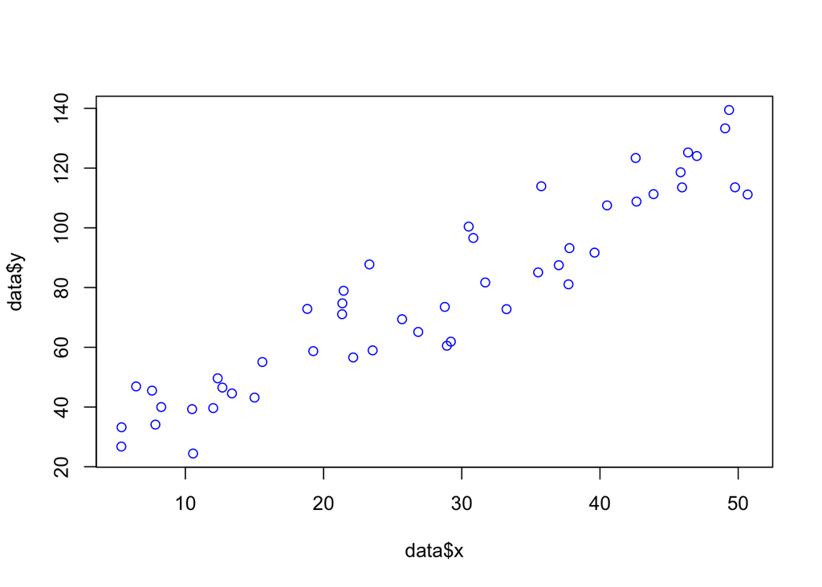

```r
plot(data$x, data$y, col = "blue", bg = "orange")
```

```r
var(data$x)
```

```
## [1] 199.9837
```

```r
var(data$y)
```

```
## [1] 977.0153
```

```r
var(data$x, data$y)
```

```
## [1] 414.9603
```

```r
var(data$x, data$y)/sqrt(var(data$x) * var(data$y))
```

```
## [1] 0.9387684
```

Correlation and Variance of Differences between Variables  
question the effect of correlation on variance of differences between variables…the variance of a difference will decline as the strength of positive correlation increases.

```r
paired <- read.csv("water.table.csv")

attach(paired)
names(paired)
```

```
## [1] "Location" "Summer"   "Winter"
```

Is there a correlation between summer and winter water table?

```r
cor(Summer, Winter)
```

```
## [1] 0.8820102
```

cor.test has non-parametric options for Kendall’s tau or Spearman’s rank

```r
cor.test(Summer, Winter)
```

```
##
##  Pearson's product-moment correlation
##
## data:  Summer and Winter
## t = 4.9521, df = 7, p-value = 0.001652
## alternative hypothesis: true correlation is not equal to 0
## 95 percent confidence interval:
##  0.5259984 0.9750087
## sample estimates:
##       cor
## 0.8820102
```

The correlation is highly significant.

relationship of three variances: Summer, Winter, and of Summer - Winter

```r
varS <- var(Summer)
varW <- var(Winter)
varD <- var(Summer - Winter)
```

Correlation coefficient:

```r
(varS + varW - varD)/(2 * sqrt(varS) * sqrt(varW))
```

```
## [1] 0.8820102
```

```r
varD
```

```
## [1] 0.01015
```

```r
varS + varW
```

```
## [1] 0.07821389
```

```r
varS + varW - 2 * 0.8820102 * sqrt(varS) * sqrt(varW)
```

```
## [1] 0.01015
```